# Homework #6 Linear Models with Categorical Variables

Nathan Strozewski

2022-10-19

# Part 1: Comparing Two Means

### Background:

```
1. In a dataset from Scantlebury et al, the authors explored how caste and mass affected the energy level of naked mole rats.
```

```r
library(readr)
library(ggplot2)
library(dplyr)
library(broom)
library(ggpmisc)
library(emmeans)
library(car)
theme_set(theme_classic(base_size = 14))
```

## Part 1a:

### Tasks:

```
1. Load the data and plotting it for initial inspection
2. We are looking at caste as a predictor of mass
```

```r
moles <- read.csv("/Users/nathanstrozewski/Documents/Everything/Education/M.S. Biology UMB/Courses/003_F2022/Biological Data Analysis/Homework/Homework #6/Data/18e4MoleRatLayabouts.csv")

str(moles)
```

```
## 'data.frame':    35 obs. of  3 variables:
##  $ caste   : chr  "worker" "worker" "worker" "worker" ...
##  $ lnmass  : num  3.85 3.99 4.11 4.17 4.25 ...
##  $ lnenergy: num  3.69 3.69 3.69 3.66 3.87 ...
```

```r
summary(moles)
```

```
##     caste               lnmass         lnenergy
##  Length:35          Min.   :3.850   Min.   :3.555
##  Class :character   1st Qu.:4.248   1st Qu.:3.902
##  Mode  :character   Median :4.511   Median :4.190
##                     Mean   :4.540   Mean   :4.193
##                     3rd Qu.:4.844   3rd Qu.:4.489
##                     Max.   :5.263   Max.   :5.043
```

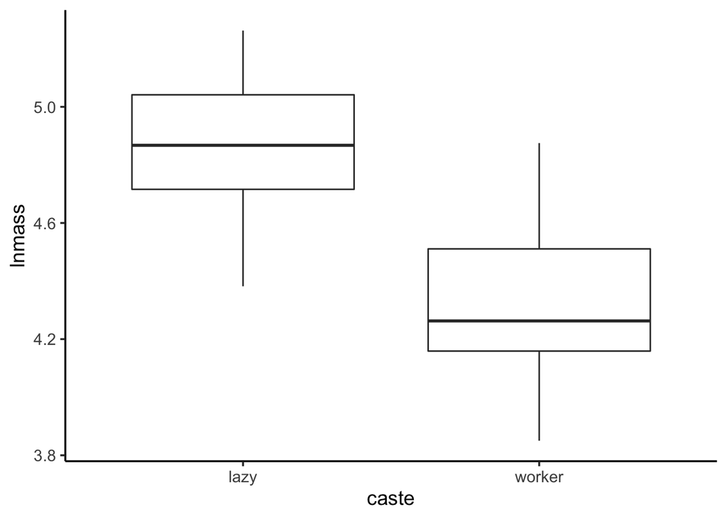

```r
ggplot(data = moles,
       mapping = aes(x = caste,
                     y = lnmass)) +
  geom_boxplot()
```

## Part 2b:

### Tasks:

```
1. Fit and evaluate the model.
2. Does it meet assumptions? Why or why not?
```

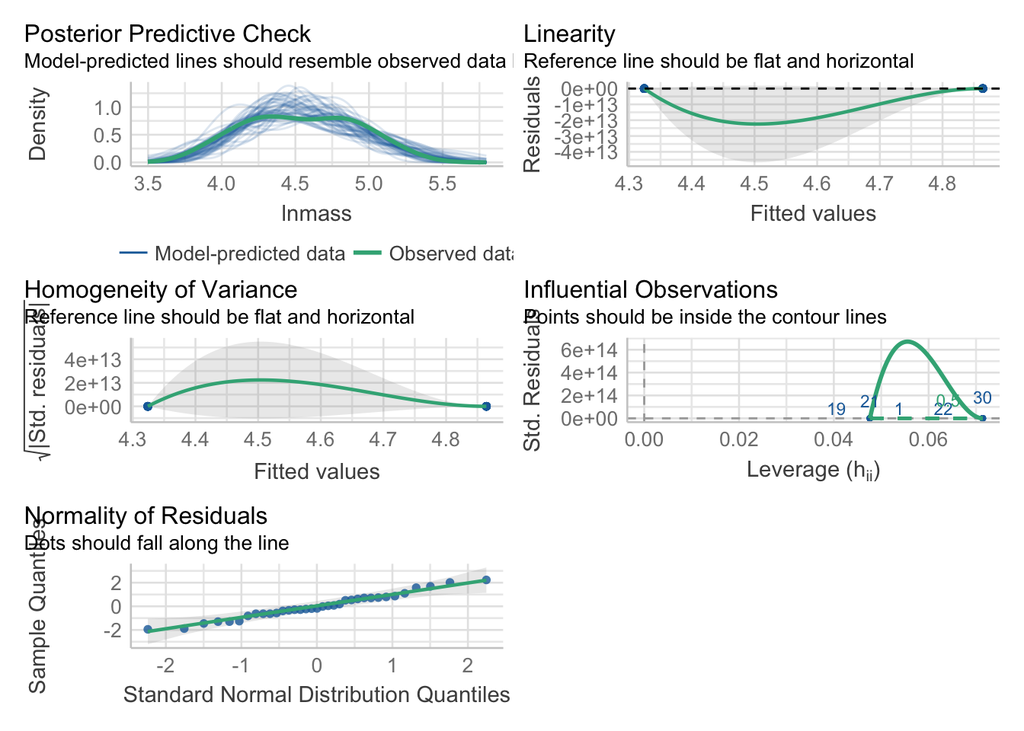

```r
library(performance)

mole_lm <- lm(lnmass ~ caste,
               data = moles)

check_model(mole_lm)
```

### Notes:

```
1. Model-predicted lines resemble observed data somewhat. Not an exact match but I am not super-concerned.
2. Data appears linear-ish; reference line is flat-ish (curved), but ultimately ends linear. Perhaps a bit non-linear?
3. Similar interpretation for homogeneity of variance
4. It is hard to see, but it seems that the data points all fall within the (very narrow) contour lines
5. Residuals look normal
```

## Part 1c & d:

### Notes:

```
1. Compare the two castes log mass values.
2. Are they different?
3. How would you discuss your conclusions?
4. Make a plot that you would feel would be clear and compelling in a publication
```

```
## No summary function supplied, defaulting to `mean_se()`
```

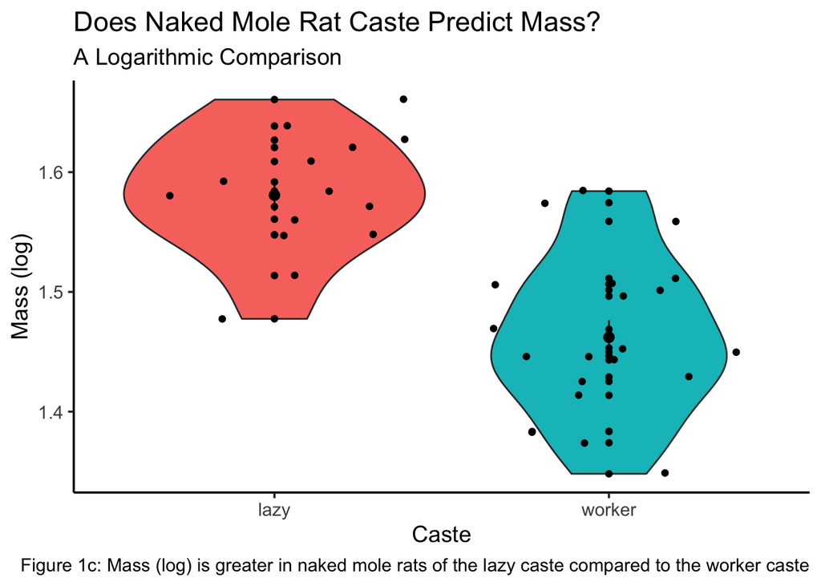

```r
moles_with_log_lnmass <- moles %>%
  mutate(log_lnmass = log(lnmass))

ggplot(data = moles_with_log_lnmass,
       mapping = aes(x = caste,
                     y = log_lnmass,
                     fill = caste)) +
  geom_violin() +
  geom_point(color = "black") +
  geom_jitter() +
  stat_summary(ffun.data = "mean_cl_boot",
               geom = "pointrange",
               colour = "black",
               width = 0.2) +
  labs(title = "Does Naked Mole Rat Caste Predict Mass?",
       subtitle = "A Logarithmic Comparison",
       caption = "Figure 1c: Mass (log) is greater in naked mole rats of the lazy caste compared to the worker caste",
       x = "Caste",
       y = "Mass (log)") +
  theme(legend.position = "none")
```

### Conclusion:

```
1. The lazy caste has a larger log(lnmass) than the worker caste
```

# Part 2:

## Background:

1. To start with, let’s warm up with a simple one-way ANOVA model
2. An example from Whitlock and Schluter (chapter 15 question 22) looks at the mass of lodgepole pinecones from different habitats

## Part 2a:

### Tasks:

```
1. Load and plot the data.
2. Choose a plot that not only shows the raw data, but also the means and SE or CI of those means.
3. Impress yourself by making it super fancy! Geom to your heart’s content.
```

```r
cones <- read.csv("/Users/nathanstrozewski/Documents/Everything/Education/M.S. Biology UMB/Courses/003_F2022/Biological Data Analysis/Homework/Homework #6/Data/15q22LodgepolePineCones.csv")

str(cones)
```

```
## 'data.frame':    16 obs. of  2 variables:
##  $ habitat : chr  "island.absent" "island.absent" "island.absent" "island.absent" ...
##  $ conemass: num  9.6 9.4 8.9 8.8 8.5 8.2 6.8 6.6 6 5.7 ...
```

```r
summary(cones)
```

```
##    habitat             conemass
##  Length:16          Min.   :5.300
##  Class :character   1st Qu.:5.925
##  Mode  :character   Median :6.650
##                     Mean   :7.150
##                     3rd Qu.:8.575
##                     Max.   :9.600
```

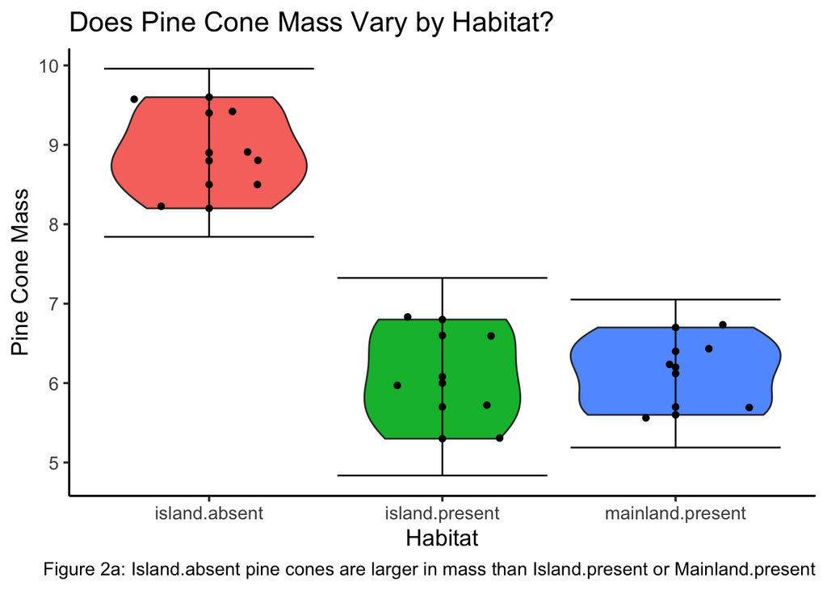

```r
ggplot(data = cones,
       mapping = aes(x = habitat,
                     y = conemass,
                     fill = habitat)) +
  geom_violin() +
  geom_point(color = "black") +
  geom_jitter() +
  stat_summary(fun = mean,
               geom = "point",
               color = "black") +
  stat_summary(fun.data = mean_sdl,
               geom = "errorbar") +
labs(title = "Does Pine Cone Mass Vary by Habitat?",
       caption = "Figure 2a: Island.absent pine cones are larger in mass than Island.present or Mainland.present",
       x = "Habitat",
       y = "Pine Cone Mass") +
  theme(legend.position = "none")
```

## Part 2b:

### Tasks:

```
1. Fit a model using least squares and evaluate all relevant assumptions.
2. List them out as you test them.
3. Can we use this model? If not, fix it. But if we can, no fix is needed!
```

```r
cones_lm <- lm(conemass ~ habitat,
               data = cones)
```

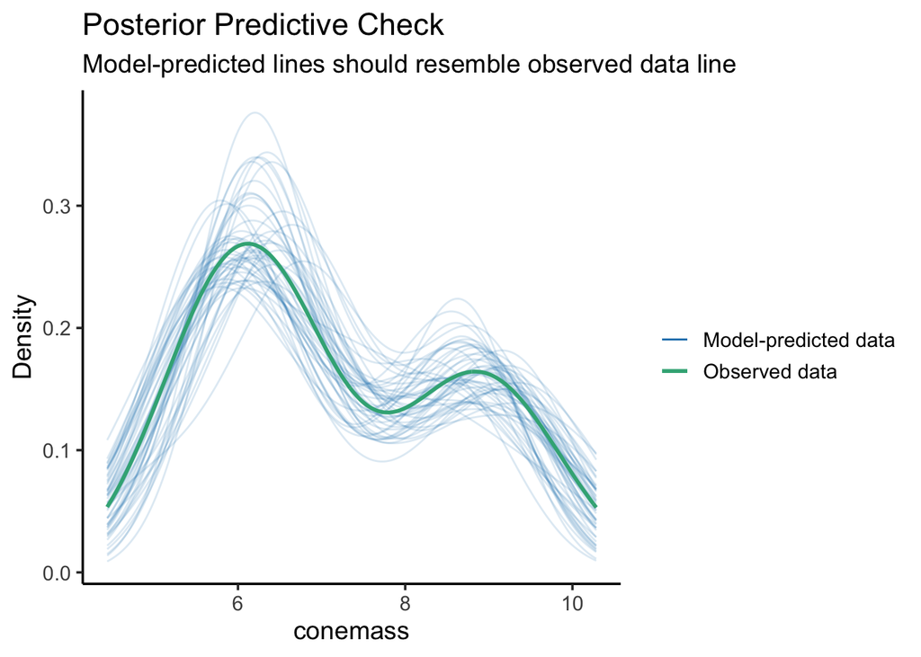

```r
check_predictions(cones_lm) %>%
  plot()
```

### Notes: Observed data fits the predicted data very closely

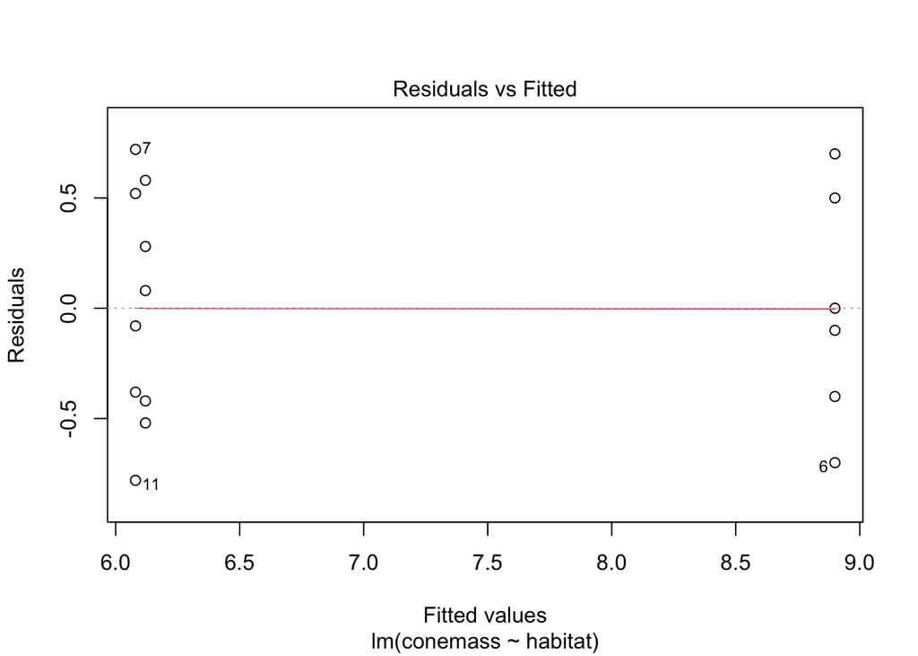

```r
plot(cones_lm, which = 1)
```

### Notes: Similar residual structures

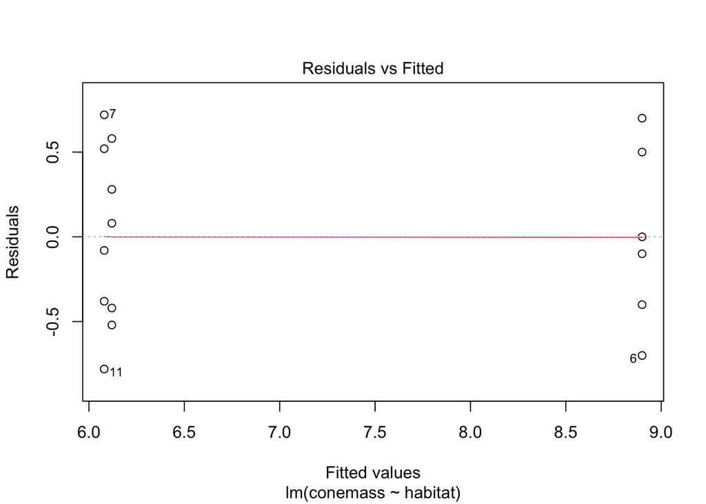

```r
plot(cones_lm, which = 1)
```

### Notes:

```
1. There is an even-ish spread dots along the Y axis for both groups. This suggests that the variance between groups is relatively even
```

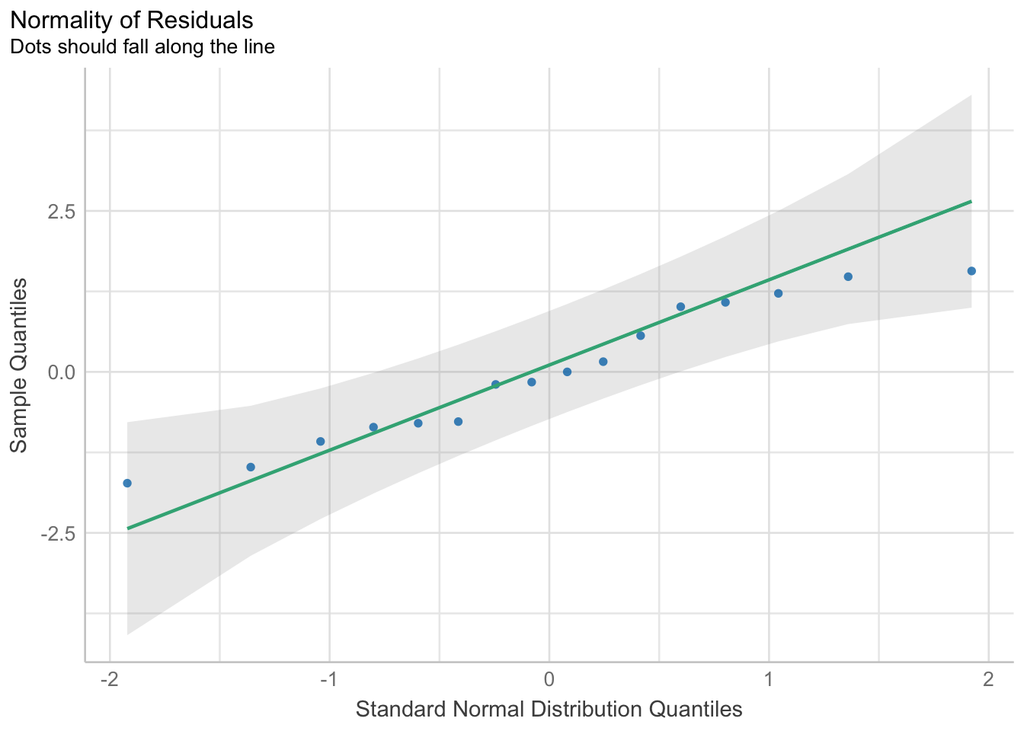

```r
check_normality(cones_lm) %>%
  plot(type = "qq")
```

### Notes: 1. The dots are mostly near the fitted line!

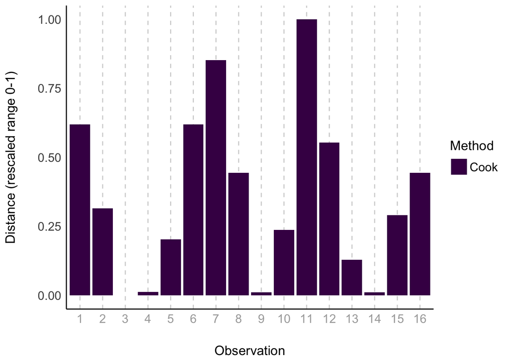

```r
check_outliers(cones_lm) %>%
  plot(type = "bar")
```

### Conclusions:

```
1. I can continue with this model with no modifications
```

## Part 2c:

### Tasks:

```
1. How much variation is explained by your model?
```

```r
summary(cones_lm)
```

```
##
## Call:
## lm(formula = conemass ~ habitat, data = cones)
##
## Residuals:
##    Min     1Q Median     3Q    Max
## -0.780 -0.405 -0.040  0.505  0.720
##
## Coefficients:
##                         Estimate Std. Error t value Pr(>|t|)
## (Intercept)               8.9000     0.2212  40.238 4.97e-15 ***
## habitatisland.present    -2.8200     0.3281  -8.596 1.01e-06 ***
## habitatmainland.present  -2.7800     0.3281  -8.474 1.18e-06 ***
## ---
## Signif. codes:  0 '***' 0.001 '**' 0.01 '*' 0.05 '.' 0.1 ' ' 1
##
## Residual standard error: 0.5418 on 13 degrees of freedom
## Multiple R-squared:  0.8851, Adjusted R-squared:  0.8675
## F-statistic: 50.09 on 2 and 13 DF,  p-value: 7.787e-07
```

### Conclusions:

```
1. Multiple R-squared is 0.8851, while adjusted R-squared is 0.8675
```

## Part 2d:

### Tasks:

```
1. Show which means are different from each other.
2. What CI are you using?
3. Are you adjusting your CIs?
4. Justify these choices.
```

```r
cones_means <- emmeans(cones_lm, specs = ~habitat)
cones_means
```

```
##  habitat          emmean    SE df lower.CL upper.CL
##  island.absent      8.90 0.221 13     8.42     9.38
##  island.present     6.08 0.242 13     5.56     6.60
##  mainland.present   6.12 0.242 13     5.60     6.64
##
## Confidence level used: 0.95
```

### Notes:

```
1. island.absent seems unique while island.present and mainland.present seem to overlap
2. I can verify this using contrast()
```

```r
cones_means_contrast <- contrast(cones_means, method = "pairwise")
cones_means_contrast
```

```
##  contrast                          estimate    SE df t.ratio p.value
##  island.absent - island.present        2.82 0.328 13   8.596  <.0001
##  island.absent - mainland.present      2.78 0.328 13   8.474  <.0001
##  island.present - mainland.present    -0.04 0.343 13  -0.117  0.9925
##
## P value adjustment: tukey method for comparing a family of 3 estimates
```

### Notes:

```
1. island.absent has a positive estimate when compared to island.present and mainland.present, suggesting that the means are unique
2. island.present has a negative estimate when compared to mainland.present, suggesting that these means are not unique
3. This is further supported by a high p-value of 0.9925
```

```r
confint(cones_means_contrast, level = 0.85)
```

```
##  contrast                          estimate    SE df lower.CL upper.CL
##  island.absent - island.present        2.82 0.328 13    2.162    3.478
##  island.absent - mainland.present      2.78 0.328 13    2.122    3.438
##  island.present - mainland.present    -0.04 0.343 13   -0.727    0.647
##
## Confidence level used: 0.85
## Conf-level adjustment: tukey method for comparing a family of 3 estimates
```

### Notes:

```
1. Nothing surprising here
2. I can plot this to further verify
```

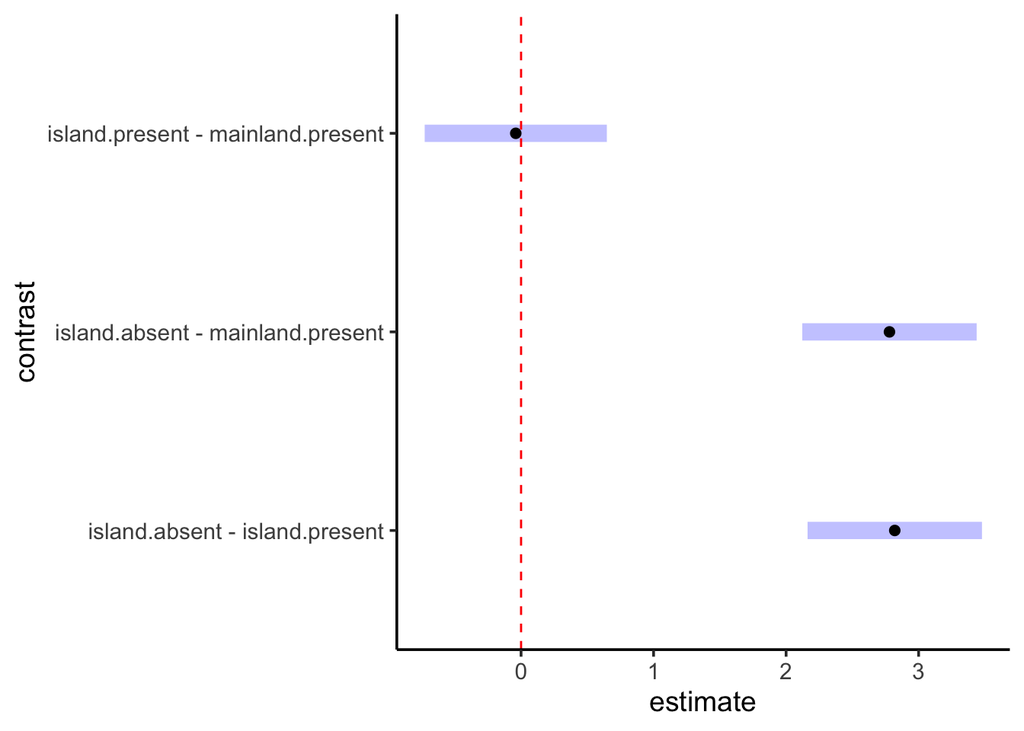

```r
plot(cones_means_contrast, level = 0.85) +
  geom_vline(xintercept = 0, lty = 2, color = "red")
```

### Notes:

[output not shown]

```r
confint(cones_means_contrast, level = 0.85)
```

```
##  contrast                          estimate    SE df lower.CL upper.CL
##  island.absent - island.present        2.82 0.328 13    2.162    3.478
##  island.absent - mainland.present      2.78 0.328 13    2.122    3.438
##  island.present - mainland.present    -0.04 0.343 13   -0.727    0.647
##
## Confidence level used: 0.85
## Conf-level adjustment: tukey method for comparing a family of 3 estimates
```

```r
confint(cones_means_contrast, level = 0.99)
```

```
##  contrast                          estimate    SE df lower.CL upper.CL
##  island.absent - island.present        2.82 0.328 13     1.67     3.97
##  island.absent - mainland.present      2.78 0.328 13     1.63     3.93
##  island.present - mainland.present    -0.04 0.343 13    -1.24     1.16
##
## Confidence level used: 0.99
## Conf-level adjustment: tukey method for comparing a family of 3 estimates
```

```r
confint(cones_means_contrast, level = 0.10)
```

```
##  contrast                          estimate    SE df lower.CL upper.CL
##  island.absent - island.present        2.82 0.328 13     2.68     2.96
##  island.absent - mainland.present      2.78 0.328 13     2.64     2.92
##  island.present - mainland.present    -0.04 0.343 13    -0.19     0.11
##
## Confidence level used: 0.1
## Conf-level adjustment: tukey method for comparing a family of 3 estimates
```

# Part 3:

## Background:

1. In a study from Rogers et al. (2020) the authors performed an experiment where they moved panels that had been colonized by invertebrates on a dock to a nearby rocky jetty where predators could access panels.
2. To separate out the effects of changes in abiotic environment versus predation, they performed a factorial experiment, either caging or not caging panels and placing them either on the side of a cinder block or hanging on a piece of PVC attached to the block where predators would have little access (but weren’t entirely stopped).
3. They then looked at change in total cover of invertebrates.

## Part 3a:

### Task:

```
1. Load the data
2. Combine cages and position into a single variable treatment
3. Plot the data. Note: we are interested in change in percent cover as influenced by the combined influence of caging and position
4. Choose a plot that not only shows the raw data, but also the means and SE or CI of those means
5. Impress yourself by making it as fancy as possible!
```

```r
foul <- read.csv("/Users/nathanstrozewski/Documents/Everything/Education/M.S. Biology UMB/Courses/003_F2022/Biological Data Analysis/Homework/Homework #6/Data/fouling_transplant_data.csv")

str(foul)
```

```
## 'data.frame':    32 obs. of  16 variables:
##  $ Treatment        : chr  "DJHC" "DJHC" "DJHC" "DJHC" ...
##  $ Caged            : chr  "Caged" "Caged" "Caged" "Caged" ...
##  $ Position.On.Block: chr  "Hanging" "Hanging" "Hanging" "Hanging" ...
##  $ botry.init       : int  13 11 21 24 14 28 14 38 17 35 ...
##  $ botry.fin        : int  13 11 21 22 12 29 17 37 10 34 ...
##  $ water.init       : int  3 5 7 23 9 13 5 8 10 20 ...
##  $ water.fin        : int  3 5 8 21 8 10 3 7 3 20 ...
##  $ diplo.init       : int  0 20 0 0 0 0 36 25 0 0 ...
##  $ diplo.fin        : int  0 25 0 0 0 0 40 43 0 0 ...
##  $ distap.init      : int  1 2 0 0 0 1 15 9 0 0 ...
##  $ distap.fin       : int  1 4 3 0 0 1 12 8 0 0 ...
##  $ bugula.init      : int  4 2 0 0 2 1 1 4 1 0 ...
##  $ bugula.fin       : int  4 3 0 0 1 1 1 4 0 0 ...
##  $ Initial.Cover    : int  21 40 28 47 25 43 71 84 28 55 ...
##  $ Final.Cover      : int  21 48 32 43 21 41 73 99 13 54 ...
##  $ Change.in.Cover  : int  0 8 4 -4 -4 -2 2 15 -15 -1 ...
```

```r
foul$Treatment.New <- paste(foul$Position.On.Block, foul$Caged)
str(foul)
```

```
## 'data.frame':    32 obs. of  17 variables:
##  $ Treatment        : chr  "DJHC" "DJHC" "DJHC" "DJHC" ...
##  $ Caged            : chr  "Caged" "Caged" "Caged" "Caged" ...
##  $ Position.On.Block: chr  "Hanging" "Hanging" "Hanging" "Hanging" ...
##  $ botry.init       : int  13 11 21 24 14 28 14 38 17 35 ...
##  $ botry.fin        : int  13 11 21 22 12 29 17 37 10 34 ...
##  $ water.init       : int  3 5 7 23 9 13 5 8 10 20 ...
##  $ water.fin        : int  3 5 8 21 8 10 3 7 3 20 ...
##  $ diplo.init       : int  0 20 0 0 0 0 36 25 0 0 ...
##  $ diplo.fin        : int  0 25 0 0 0 0 40 43 0 0 ...
##  $ distap.init      : int  1 2 0 0 0 1 15 9 0 0 ...
##  $ distap.fin       : int  1 4 3 0 0 1 12 8 0 0 ...
##  $ bugula.init      : int  4 2 0 0 2 1 1 4 1 0 ...
##  $ bugula.fin       : int  4 3 0 0 1 1 1 4 0 0 ...
##  $ Initial.Cover    : int  21 40 28 47 25 43 71 84 28 55 ...
##  $ Final.Cover      : int  21 48 32 43 21 41 73 99 13 54 ...
##  $ Change.in.Cover  : int  0 8 4 -4 -4 -2 2 15 -15 -1 ...
##  $ Treatment.New    : chr  "Hanging Caged" "Hanging Caged" "Hanging Caged" "Hanging Caged" ...
```

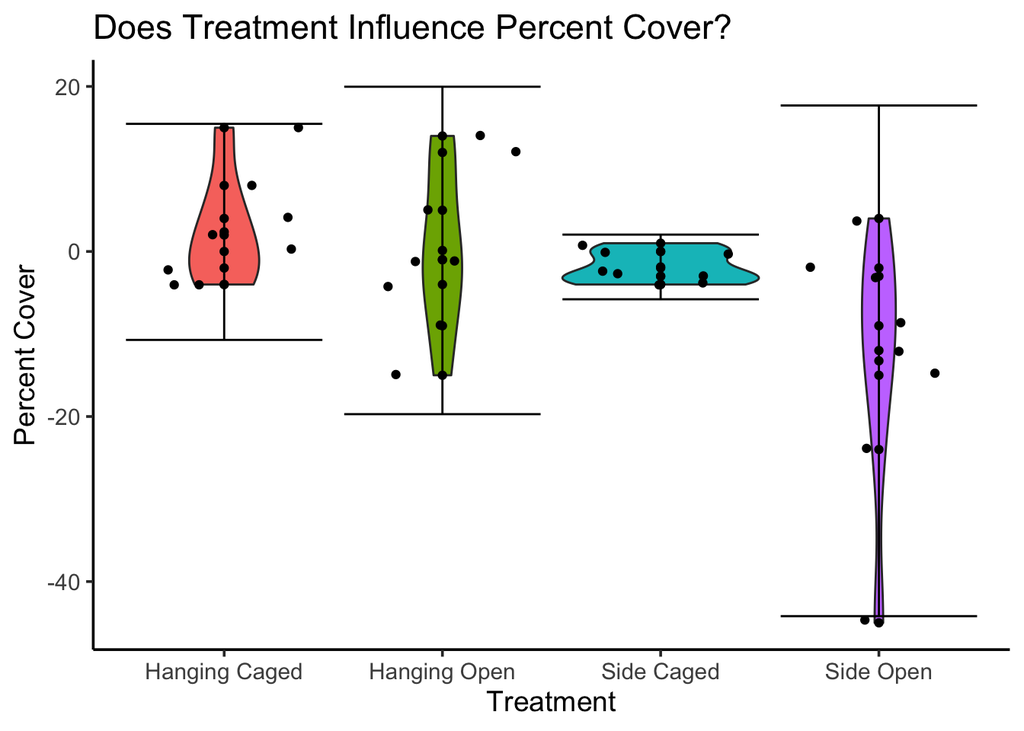

```r
part_3a <- ggplot(
  data = foul,
  mapping = aes(x = Treatment.New,
                y = Change.in.Cover,
                fill = Treatment.New)
) +
  geom_violin() +
  geom_point(color = "black") +
  geom_jitter() +
  stat_summary(fun = mean,
               geom = "point",
               color = "black") +
  stat_summary(fun.data = mean_sdl,
               geom = "errorbar") +
  labs(title = "Does Treatment Influence Percent Cover?",
       x = "Treatment",
       y = "Percent Cover") +
  theme(legend.position = "none")
part_3a
```

## Part 3b:

### Tasks:

```
1. Fit a model looking at how treatment influences cover change and evaluate all relevant assumptions.
2. Do you meet assumptions?
```

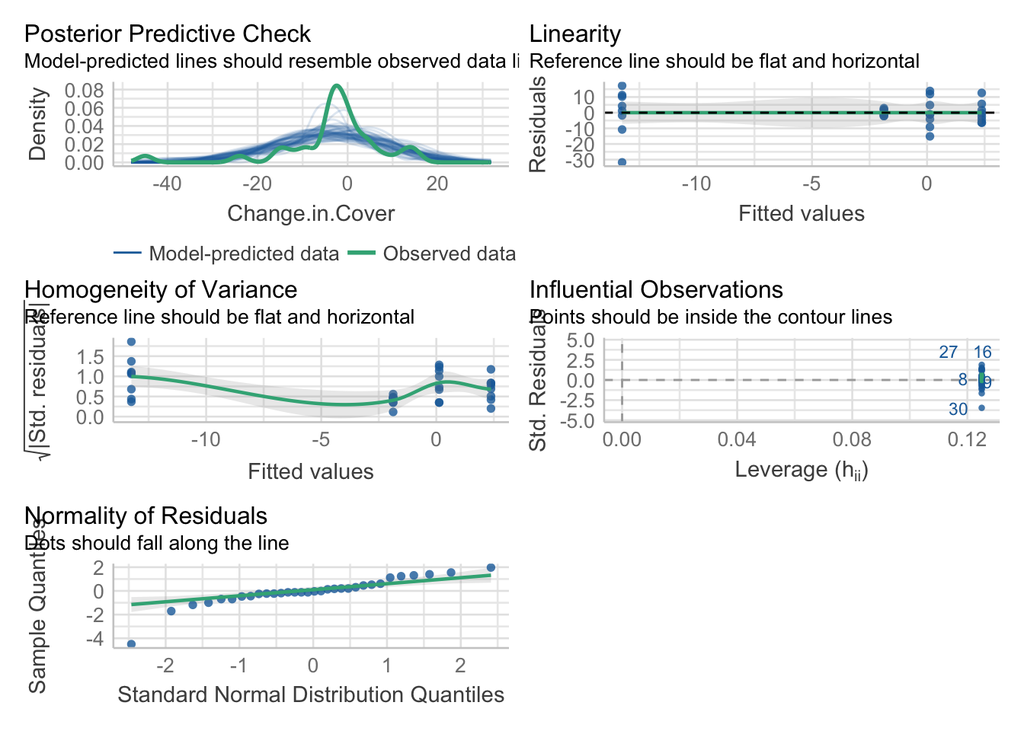

```r
foul_lm <- lm(Change.in.Cover ~ Treatment.New,
              data = foul)
check_model(foul_lm)
```

### Notes: 1. The observed and predicted data aren’t a super close match but generally the same shape? 2. The data is nearly linear but not quite 3. The comparisons have very different variances 4. No big issues with normality 5. No big issues with outliers

### Conclusions:

```
1. The data does not meet assumptions
```

## Part 3c:

### Notes:

```
1. If you answered yes to the above...you are wrong. It doesn’t! Percentage data is weird. Difference in percentages can be ever weirder!
```

### Tasks:

```
1. Divide change by initial cover to express change as percent change relative to initial cover.
2. Calculate difference in logit cover (so, logist(initial cover) - logit(final cover)).
3. Which one works (or at least works better) so that you can produce valid inference?
```

```r
foul_part_3c_1 <- foul %>%
  mutate(PCR_to_IC = Change.in.Cover / Initial.Cover)
foul_part_3c_1
```

```
##    Treatment Caged Position.On.Block botry.init botry.fin water.init water.fin
## 1       DJHC Caged           Hanging         13        13          3         3
## 2       DJHC Caged           Hanging         11        11          5         5
## 3       DJHC Caged           Hanging         21        21          7         8
## 4       DJHC Caged           Hanging         24        22         23        21
## 5       DJHC Caged           Hanging         14        12          9         8
## 6       DJHC Caged           Hanging         28        29         13        10
## 7       DJHC Caged           Hanging         14        17          5         3
## 8       DJHC Caged           Hanging         38        37          8         7
## 9       DJHO  Open           Hanging         17        10         10         3
## 10      DJHO  Open           Hanging         35        34         20        20
## 11      DJHO  Open           Hanging         12        11          7         7
## 12      DJHO  Open           Hanging         24        23         11         7
## 13      DJHO  Open           Hanging         16        15          6         6
## 14      DJHO  Open           Hanging         18        16         18        11
```

[output cut: 84 more lines]

```r
foul_part_3c_2 <- foul_part_3c_1 %>%
  mutate(logit_cover = logit(Initial.Cover) - logit(Final.Cover))
```

```
## Note: largest value of p > 1 so values of p interpreted as percents
## Note: largest value of p > 1 so values of p interpreted as percents
```

```r
foul_part_3c_2
```

```
##    Treatment Caged Position.On.Block botry.init botry.fin water.init water.fin
## 1       DJHC Caged           Hanging         13        13          3         3
## 2       DJHC Caged           Hanging         11        11          5         5
## 3       DJHC Caged           Hanging         21        21          7         8
## 4       DJHC Caged           Hanging         24        22         23        21
## 5       DJHC Caged           Hanging         14        12          9         8
## 6       DJHC Caged           Hanging         28        29         13        10
## 7       DJHC Caged           Hanging         14        17          5         3
## 8       DJHC Caged           Hanging         38        37          8         7
## 9       DJHO  Open           Hanging         17        10         10         3
## 10      DJHO  Open           Hanging         35        34         20        20
## 11      DJHO  Open           Hanging         12        11          7         7
## 12      DJHO  Open           Hanging         24        23         11         7
## 13      DJHO  Open           Hanging         16        15          6         6
## 14      DJHO  Open           Hanging         18        16         18        11
```

[output cut: 117 more lines]

### Notes:

```
1. The two methods produced different values.
   a. logit calculations are larger than dividing change in cover by initial cover
   b. Positive values in the former are negative in the latter, and vice versa
   c. I guess this makes sense when you consider logs
```

## Part 3d:

### What does this fit model tell you about how and which treatments differ in change?

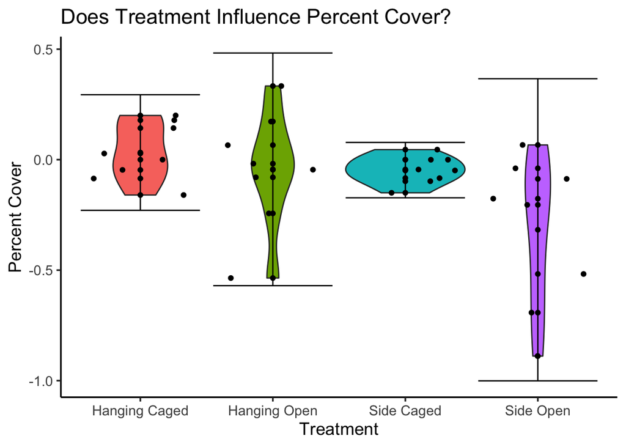

```r
part_3d <- ggplot(
  data = foul_part_3c_2,
  mapping = aes(x = Treatment.New,
                y = PCR_to_IC,
                fill = Treatment.New)
) +
  geom_violin() +
  geom_point(color = "black") +
  geom_jitter() +
  stat_summary(fun = mean,
               geom = "point",
               color = "black") +
  stat_summary(fun.data = mean_sdl,
               geom = "errorbar") +
  labs(title = "Does Treatment Influence Percent Cover?",
       x = "Treatment",
       y = "Percent Cover") +
  theme(legend.position = "none")
part_3d
```

### Notes:

[output not shown]

# Part 4: Meta Questions

## Meta 1:

### Are you starting to see the connections between linear regression and models with categorical variables?

```
1. Yes, it has clicked well for me
2. These types of models plot really well for easy comparison, particularly with violin plots
```

### What about this week surprised you the most?

```
1. Nothing particularly surprised me this week. I think the content flowed really well with that from last week. The two build well off of each other.
```

## Meta 2:

### What about what we did this week was the most difficult for you to understand?

[output not shown]

### Where are you feeling the boundaries of your understanding pushed the most?

```
1. It is really easy for me to find one method of visualizing data that works ok-ish and stick with that. I need to continue pressing myself to formulate the best way to visualize each individual dataset to answer a question or demonstrate the findings
```

## Meta 3:

### How much time did this take you, roughly?

```
1. 3.5 hours
```

## Meta 4:

### Please give yourself a weak/sufficient/strong assessment on this assigment. Feel free to comment on why.

[output not shown]